# Redes Neuronales: entendiendo el núcleo de la IA

Claudio Sebastián Castillo

14 de noviembre de 2022

# Introducción

El *deep learning* es un área sumamente bella del *machine learning* y no estoy pensando en sus resultados sino en la riqueza de sus arquitecturas y la sutileza de sus composiciones algorítmicas. Una forma de apreciar esa belleza en mi caso ha pasado por comprender estos complejos mecanismos a partir de sus elementos simples. Intentar mirar con auténtica curiosidad y ánimo de juego, cómo funcionan las *redes neuronales*.

Por eso en este documento construiremos nuestra propia red neuronal desde cero.Esta red será básica: tendrá una sola capa oculta y servirá para una clasificación binaria. Aún en su simpleza esta red contendrá todos los elementos que hacen funcionar a estas unidades de aprendizaje y todas las arquitecturas basadas en ellas.

Para este proyecto armaremos nuestra red parte por parte, comenzando con las funciones que sirven para inicializar los parámetros de la red, algo así como el estado 0 de aprendizaje (una *tabula rasa*) y luego las funciones de propagación hacia adelante y hacia atrás. Armaremos la función para calcular el gradientes y actualizar los pesos. Finalmente, haremos predicciones sobre los datos de test y veremos qué tan preciso es nuestro modelo (Exactitud, Recuperación, Precisión y F1) comparándolo con un modelo de regresión logística.

Al final de esta serie esperamos haber recorrido los distintos elementos de este maravilloso artefacto que son las *redes neuronales* como así también ganar una intuición más profunda de lo que implican las grandes arquitecturas que hoy pueblan el campo de la *Inteligencia Artificial*.

Este documento fue elaborado a partir de la publicación del 2020-07-20 de Akshaj Verma (India) a quién deben darse los créditos por el maravilloso experimento de aprendizaje. Ver publicación [aquí](https://rviews.rstudio.com/2020/07/20/shallow-neural-net-from-scratch-using-r-part-1/).

# Preparamos datos, ambiente y algunas librerías

```r
set.seed(777)
library(dplyr)
library(ggplot2)
```

## Creamos dataset para el experimento

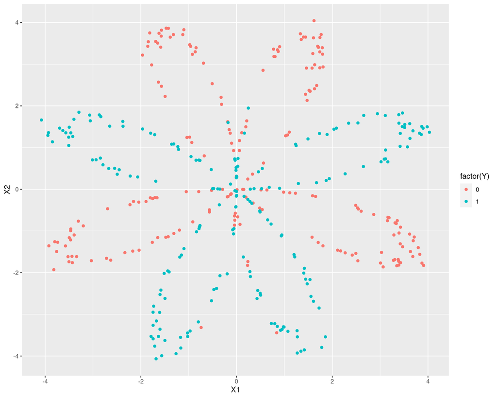

```r
planar_dataset <- function(){
  set.seed(1)
  m <- 400
  N <- m/2
  D <- 2
  X <- matrix(0, nrow = m, ncol = D)
  Y <- matrix(0, nrow = m, ncol = 1)
  a <- 4

  for(j in 0:1){
    ix <- seq((N*j)+1, N*(j+1))
    t <- seq(j*3.12,(j+1)*3.12,length.out = N) + rnorm(N, sd = 0.2)
    r <- a*sin(4*t) + rnorm(N, sd = 0.2)
    X[ix,1] <- r*sin(t)
    X[ix,2] <- r*cos(t)
    Y[ix,] <- j
  }

  d <- as.data.frame(cbind(X, Y))
  names(d) <- c('X1','X2','Y')
  d
}

# try out
df <- planar_dataset()

ggplot(df, aes(x = X1, y = X2, color = factor(Y))) +
  geom_point()
```

## Mezclamos los datos

```r
df <- df[sample(nrow(df)), ]
```

## Separacion dataset Train-Test

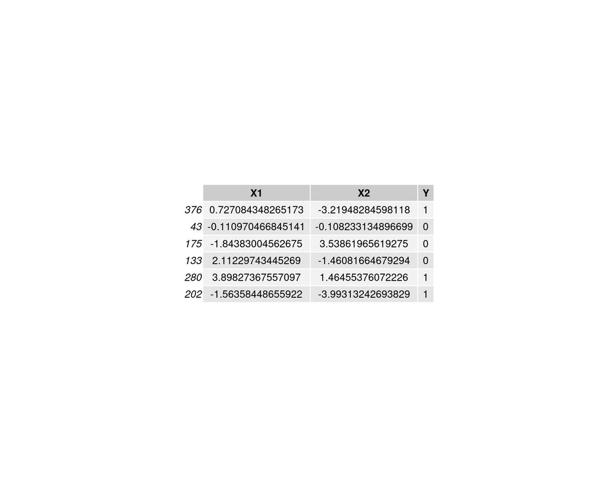

```r
train_test_split_index <- 0.8 * nrow(df)
train <- df[1:train_test_split_index,]
test <- df[(train_test_split_index+1): nrow(df),]
train %>% head() %>%
  gridExtra::grid.table()
```

## Preprocesamiento

Las redes neuronales funcionan mejor cuando los valores de entrada están estandarizados. Entonces, escalaremos todos los valores para que tengan su media = 0 y su desviación estándar = 1. La estandarización de los valores de entrada acelera el entrenamiento.

```r
X_train <- scale(train[, c(1:2)])

y_train <- train$Y
dim(y_train) <- c(length(y_train), 1) # add extra dimension to vector

X_test <- scale(test[, c(1:2)])

y_test <- test$Y
dim(y_test) <- c(length(y_test), 1)
```

## Convertimos dataframes en matrices

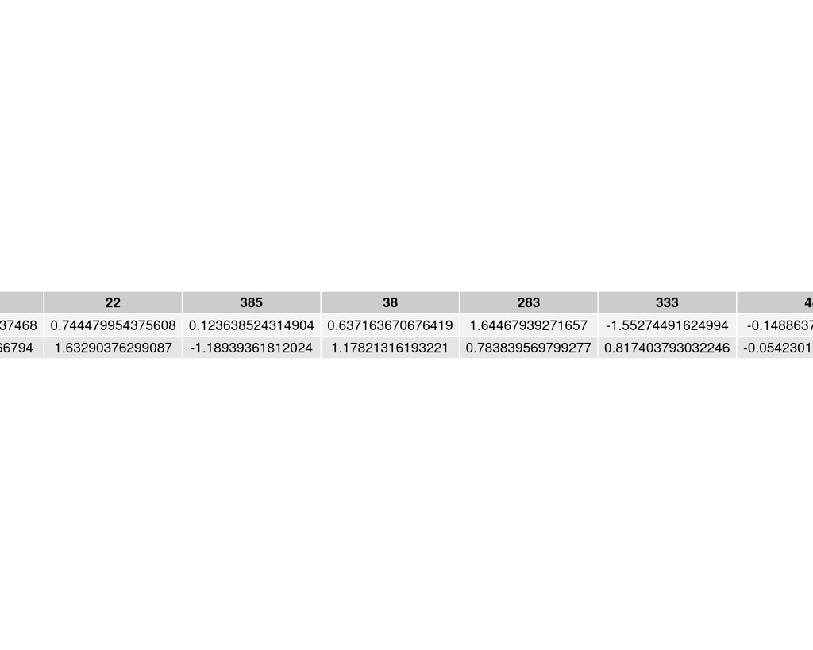

```r
X_train <- as.matrix(X_train, byrow=TRUE)
X_train <- t(X_train)
y_train <- as.matrix(y_train, byrow=TRUE)
y_train <- t(y_train)

X_test <- as.matrix(X_test, byrow=TRUE)
X_test <- t(X_test)
y_test <- as.matrix(y_test, byrow=TRUE)
y_test <- t(y_test)

X_train %>% head() %>%
  gridExtra::grid.table()
```

# Armamos nuestra red neuronal

La pieza de construcción central de una red está dada por sus capas o *layers*, que puede ser vistas como *módulos de procesamiento* de los datos. Es decir, los datos encuentran en cada *layer* a una estructura compuesta por ciertas operaciones matriciales y cierta información para realizar esas operaciones. Información que se denomina *weights* o *parámetros de la red*.

En nuestro caso, describiremos una red neuronal simple de 3 capas con una sola capa oculta. La primera capa está dada por los datos de entrenamiento (atributos o variables), la tercera capa genera los outputs o salidas para nuestra clasificación, la segunda capa es la capa oculta. La capa de entrada tendrá dos neuronas (una por cada atributo o columna del dataset), la capa oculta cuatro neuronas (que puede entenderse como un indicador de la complejidad que tiene la red y las transformaciones que realizará en los datos) y la de salida una sola neurona (porque estamos haciendo una clasifición binaria 0 o 1 para lo cual una simple transformación tipo sigmoidea es suficiente).

Hay que tener en cuenta que esta estructura es una simplificación. Las redes neuronales pueden tener múltiples capas con miles de neuronas (o unidades de procesamiento).

Las redes neuronales emplean cálculo matricial (más específicamente operaciones sobre tensores) para las transformaciones matemáticas que aplican a los datos. De hecho los datos no son otra cosa que tensores de números (arreglos de N dimensiones) que codifican la información disponible. Las operaciones son formas de manipular/transformar los datos de entrada con el fin de lograr representaciones útiles para la tarea objetivo. Estas transformaciones van generando la información que necesita la red (y que captura en sus parámetros -más de esto en un rato-) para poder relacionar ciertos datos de entrada con la clase que le corresponde.

Entrenar una red neuronal generalmente supone los siguientes pasos:

- inicializar los parámetros del modelo a partir de una distribución aleatoria uniforme, y
- iterar cumpliendo con:
  - implementar propagación hacia adelante,
  - calcular pérdida, y
  - implemente propagación hacia atrás para ajustar parámetro.

Por eso a continuación veremos las funciones que nos permitirán cumplir con ese propósito.

## Tamaño de las capas neuronales de la red

Una red neuronal aprende a través del proceso de entrenamiento y ese aprendizaje queda *almacenado* en sus parámetros o *weights* que están en sus capas. Dichos parámetros adquieren inicialmente valores aleatorios (por eso los primeros resultados de las predicciones no suponen aprendizaje alguno), pero a medida que se generan nuevas iteraciones dichos parámetros se van ajustando para minimizar el error de predicción como ya veremos. Es importante resaltar que dichos parámetros son matrices de valores que forman parte de la capa de la red y que permiten efectuar las operaciones matriciales que transforman entradas en salidas. Dichas matrices tienen una dimensión que depende del número de neuronas en cada capa de la red.Veamos la función que extrae esta información.

```r
getLayerSize <- function(X, y, hidden_neurons, train=TRUE) {
  n_x <- dim(X)[1]
  n_h <- hidden_neurons
  n_y <- dim(y)[1]

  size <- list("n_x" = n_x,
               "n_h" = n_h,
               "n_y" = n_y)

  return(size)
}
```

```r
layer_size <- getLayerSize(X_train, y_train, hidden_neurons = 4)
layer_size
```

```
## $n_x
## [1] 2
##
## $n_h
## [1] 4
##
## $n_y
## [1] 1
```

## Inicialización aleatoria de los parámetros de la red

Antes de comenzar a entrenar nuestros parámetros, debemos inicializarlos para lo cual emplearemos una distribución uniforme aleatoria. La función `initializeParameters()` toma como argumento una matriz de entrada y una lista que contiene los tamaños de las capas, es decir, el número de neuronas. La función devuelve los parámetros entrenables W1, b1, W2, b2.

Nuestra red neuronal tiene 3 capas, lo que nos da 2 conjuntos de parámetros o 4 matrices. El primer conjunto es W1 y b1. El segundo conjunto es W2 y b2. Los tamaños de estas matrices de pesos son:

- W1 = (n_h, n_x)
- b1 = (n_h, 1)
- W2 = (n_y, n_h)
- b2 = (n_y, 1)

```r
initializeParameters <- function(X, list_layer_size){

    m <- dim(data.matrix(X))[2]

    n_x <- list_layer_size$n_x
    n_h <- list_layer_size$n_h
    n_y <- list_layer_size$n_y

    W1 <- matrix(runif(n_h * n_x), nrow = n_h, ncol = n_x, byrow = TRUE) * 0.01
    b1 <- matrix(rep(0, n_h), nrow = n_h)
    W2 <- matrix(runif(n_y * n_h), nrow = n_y, ncol = n_h, byrow = TRUE) * 0.01
    b2 <- matrix(rep(0, n_y), nrow = n_y)

    params <- list("W1" = W1,
                   "b1" = b1,
                   "W2" = W2,
                   "b2" = b2)

    return (params)
}
```

Para nuestra red, el tamaño de nuestras matrices tiene los siguientes valores:

```r
init_params <- initializeParameters(X_train, layer_size)
lapply(init_params, function(x) dim(x))
```

```
## $W1
## [1] 4 2
##
## $b1
## [1] 4 1
##
## $W2
## [1] 1 4
##
## $b2
## [1] 1 1
```

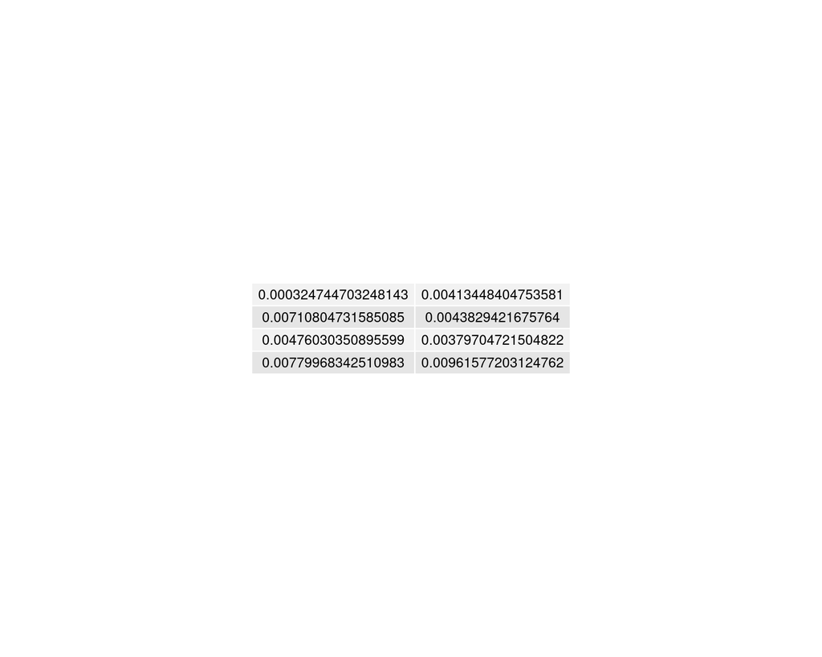

```r
init_params$W1 %>%
  gridExtra::grid.table()
```

## Definimos la función sigmoidea

```r
sigmoid <- function(x){
    return(1 / (1 + exp(-x)))
}
```

# Fowardpropagation: tranformaciones hacia delante y weights

En este punto tomamos los elementos creados antes, a saber: la matriz de datos y los parámetros, y efectuamos la transformación de datos mediante multiplicación matricial.

Nótese que esta operación es una forma de transformar los datos de entrada con el fin de que la transformación resultante contenga una representación distinta y más útil para la tarea de clasificación que se está realizando. Esta transformación, basada en operaciones elementales de multiplicación y suma de matrices, convierte la información codificada en los atributos de entrada en nuevos atributos y al hacerlo van reteniendo en los *weights* los valores que los generaron. Esta información, almacenada bajo la forma de una matriz de valores, es la *memoria de la neurona*, constituida por una matriz de valores que se van ajustando con las iteracciones de entrenamiento (*epoch*). Así, cada predicción tiene lugar en una cadena de sucesivas predicciones cuyo error (discrepancia verdad-predicción) se busca minimizar.

```r
forwardPropagation <- function(X, params, list_layer_size){

    m <- dim(X)[2]
    n_h <- list_layer_size$n_h
    n_y <- list_layer_size$n_y

    W1 <- params$W1
    b1 <- params$b1
    W2 <- params$W2
    b2 <- params$b2

    b1_new <- matrix(rep(b1, m), nrow = n_h)
    b2_new <- matrix(rep(b2, m), nrow = n_y)

    # z = init_params$W1 %*% X_train +
    #       (matrix(rep(init_params$b1, dim(X_train)[2]), layer_size$n_h))

    Z1 <- W1 %*% X + b1_new
    A1 <- tanh(Z1)         # Función de Activación: tanh entre -1/1
                           # introducen no-linealidad en la red (sin ella
                           # todas las operaciones matriciales son lineales)
                           # hacen posible el aprendizaje de funciones
                           # no lineales en los datos.
    Z2 <- W2 %*% A1 + b2_new
    A2 <- sigmoid(Z2)         # Función de Activación

    cache <- list("Z1" = Z1,
                  "A1" = A1,
                  "Z2" = Z2,
                  "A2" = A2)

    return (cache)
}
```

```r
fwd_prop <- forwardPropagation(X_train, init_params, layer_size)
lapply(fwd_prop, function(x) dim(x))
```

```
## $Z1
## [1]   4 320
##
## $A1
## [1]   4 320
##
## $Z2
## [1]   1 320
##
## $A2
## [1]   1 320
```

# Calculámos el error de las predicciones

Para el error de predicción de nuestra red neuronal vamos a utilizar la función de entropía cruzada (o *log loss*)

```r
computeCost <- function(X, y, cache) {
    m <- dim(X)[2]
    A2 <- cache$A2
    logprobs <- (log(A2) * y) + (log(1-A2) * (1-y))
    cost <- -sum(logprobs/m)
    return (cost)
}
```

```r
cost <- computeCost(X_train, y_train, fwd_prop)
cost
```

```
## [1] 0.6931702
```

# Backpropagation: Derivada y ajuste hacia atrás de los weights

Este es el corazón de la red donde se ajustan los parámetros en dirección a mejorar las predicciones.

Vimos hasta aquí que llegamos a predicciones y a determinar un error residual global y por observación. Llegamos a ese resultado a través de operaciones de transformación matricial cuyos parámetros son conocidos para la red. Por eso tenemos las piezas de información requeridas para dar un paso fundamental en términos de aprendizaje: modificar los parámetros para reducir el error. Como podemos minimizar el error cambiando los valores de las matrices empleadas para producir las predicciones? Supongamos que dejamos todos los parámetros sin cambio y actualizamos un solo valor. De esa forma con dos operaciones sabríamos hacia donde cambiar el valor del parámetro para mejorar disminuir el error. Pero este enfoque es impracticable en nuestro caso -y en general- pues la red tiene muchos parámetros. Por fortuna todas las operaciones empleadas en nuestra red son diferenciables, es decir se le puede calcular el gradiente del error a partir de los parámetros de la red (matrices de *weights*). Una vez más viene al rescate “la derivada”!. La derivada se calcula sobre los *weights* para obtener (analíticamente) sus valores derivados, y lo que se busca es la magnitud de incremento/decremento de estos valores en dirección opuesta al gradiente de la función de pérdida. Esta cambio en los parámetros, este ajuste diferencial hacia atrás, permite mediante pequeños cambios en los parámetros disminuir el error en la predicción y el error total del modelo.

Veamos la función que calculará el gradiente de los parámetros.

```r
backwardPropagation <- function(X, y, cache, params, list_layer_size){

    m <- dim(X)[2]

    n_x <- list_layer_size$n_x
    n_h <- list_layer_size$n_h
    n_y <- list_layer_size$n_y

    A2 <- cache$A2
    A1 <- cache$A1
    W2 <- params$W2

    dZ2 <- A2 - y # error residual
    dW2 <- 1/m * (dZ2 %*% t(A1))  # A1 weight aprendidos de la primer capa
    db2 <- matrix(1/m * sum(dZ2), nrow = n_y)
    db2_new <- matrix(rep(db2, m), nrow = n_y)

    dZ1 <- (t(W2) %*% dZ2) * (1 - A1^2)
    dW1 <- 1/m * (dZ1 %*% t(X))
    db1 <- matrix(1/m * sum(dZ1), nrow = n_h)
    db1_new <- matrix(rep(db1, m), nrow = n_h)

    grads <- list("dW1" = dW1, # derivada de W1
                  "db1" = db1,
                  "dW2" = dW2,
                  "db2" = db2)

    return(grads)
}
```

```r
back_prop <- backwardPropagation(X_train, y_train, fwd_prop, init_params, layer_size)
lapply(back_prop, function(x) dim(x))
```

```
## $dW1
## [1] 4 2
##
## $db1
## [1] 4 1
##
## $dW2
## [1] 1 4
##
## $db2
## [1] 1 1
```

# Actualización de parámetros

A partir de los gradientes calculados `porBACKPropagation()`, actualizamos nuestros *weights* usando la función `updateParameters()`. La función toma como argumentos los gradientes, los parámetros de red y una *tasa de aprendizaje*

¿Por qué una tasa de aprendizaje? Porque a veces las actualizaciones de peso (gradientes) son demasiado grandes y eso podría generar un problema en el proceso de optimización por el cual se busca minimizar el error. La tasa de aprendizaje es un hiperparámetro que establecemos nosotros para controlar el impacto de las actualizaciones de los pesos. El valor de la tasa de aprendizaje se encuentra entre 0 y 1. Esta tasa de aprendizaje se multiplica con los gradientes antes de restarse de los pesos.

```r
updateParameters <- function(grads, params, learning_rate){

    W1 <- params$W1
    b1 <- params$b1
    W2 <- params$W2
    b2 <- params$b2

    dW1 <- grads$dW1
    db1 <- grads$db1
    dW2 <- grads$dW2
    db2 <- grads$db2


    W1 <- W1 - learning_rate * dW1
    b1 <- b1 - learning_rate * db1
    W2 <- W2 - learning_rate * dW2
    b2 <- b2 - learning_rate * db2

    updated_params <- list("W1" = W1,
                           "b1" = b1,
                           "W2" = W2,
                           "b2" = b2)

    return (updated_params)
}
```

```r
update_params <- updateParameters(back_prop, init_params, learning_rate = 0.01)
lapply(update_params, function(x) dim(x))
```

```
## $W1
## [1] 4 2
##
## $b1
## [1] 4 1
##
## $W2
## [1] 1 4
##
## $b2
## [1] 1 1
```

# Entrenamiento de la red neuronal

Ahora que tenemos todos los elementos de la red crearemos la función que entrenará nuestro modelo. Usaremos todas las funciones que armamos en el siguiente orden.

- Ejecutar propagación hacia adelante
- Calcular pérdida
- Calcular gradientes
- Actualizar parámetros
- Repetir

Esta función `trainModel()` toma como argumentos la matriz de entrada X, las etiquetas verdaderas y y el número de épocas.

1- Obtenrt los tamaños de las capas (*leyers*) e inicializar parámetros aleatorios.  
2- Creamos un vector llamado `cost_history` para almacenar el valor de pérdida por caada iteración de la red (o *epoch*). 3- Iteramos: - Ejecutamos propagación hacia delante.  
- Calculamos pérdida.  
- Actualizamos parámetros.

```r
trainModel <- function(X, y, num_iteration, hidden_neurons, lr){

    layer_size <- getLayerSize(X, y, hidden_neurons)
    init_params <- initializeParameters(X, layer_size)
    cost_history <- c()
    for (i in 1:num_iteration) {
        fwd_prop <- forwardPropagation(X, init_params, layer_size)
        cost <- computeCost(X, y, fwd_prop)
        back_prop <- backwardPropagation(X, y, fwd_prop, init_params, layer_size)
        update_params <- updateParameters(back_prop, init_params, learning_rate = lr)
        init_params <- update_params
        cost_history <- c(cost_history, cost)

        if (i %% 10000 == 0) cat("Iteration", i, " | Cost: ", cost, "\n")
    }

    model_out <- list("updated_params" = update_params,
                      "cost_hist" = cost_history)
    return (model_out)
}
```

## Parámetros del entrenamiento

```r
EPOCHS = 60000
HIDDEN_NEURONS = 40
LEARNING_RATE = 0.9
```

```r
train_model <- trainModel(X_train, y_train, hidden_neurons = HIDDEN_NEURONS, num_iteration = EPOCHS, lr = LEARNING_RATE)
```

```
## Iteration 10000  | Cost:  0.1821798
## Iteration 20000  | Cost:  0.1444739
## Iteration 30000  | Cost:  0.1394876
## Iteration 40000  | Cost:  0.1370455
## Iteration 50000  | Cost:  0.1357737
## Iteration 60000  | Cost:  0.1309273
```

```r
makePrediction <- function(X, y, hidden_neurons){
    layer_size <- getLayerSize(X, y, hidden_neurons)
    params <- train_model$updated_params
    fwd_prop <- forwardPropagation(X, params, layer_size)
    pred <- fwd_prop$A2

    return (pred)
}
```

## Realizamos predicciones

```r
y_pred <- makePrediction(X_test, y_test, HIDDEN_NEURONS)
y_pred <- round(y_pred)
```

# Creamos Regresion Logística para comparar modelos

```r
lr_model <- glm(Y ~ X1 + X2, data = train, family="binomial")
lr_pred <- round(as.vector(predict(lr_model, test[, 1:2])))
```

## Resultado de la comparación

```r
tb_nn <- table(y_test, y_pred)
tb_lr <- table(y_test, lr_pred)
```

```r
calculate_stats <- function(tb, model_name) {
  acc <- (tb[1] + tb[4])/(tb[1] + tb[2] + tb[3] + tb[4])
  recall <- tb[4]/(tb[4] + tb[3])
  precision <- tb[4]/(tb[4] + tb[2])
  f1 <- 2 * ((precision * recall) / (precision + recall))

  cat(model_name, ": \n")
  cat("\tAccuracy = ", acc*100, "%.")
  cat("\n\tPrecision = ", precision*100, "%.")
  cat("\n\tRecall = ", recall*100, "%.")
  cat("\n\tF1 Score = ", f1*100, "%.\n\n")
}
```

## resultados RL

```r
calculate_stats(tb_lr, "RegresionLogística")
```

```
## RegresionLogística :
##  Accuracy =  55.38462 %.
##  Precision =  83.33333 %.
##  Recall =  51.02041 %.
##  F1 Score =  63.29114 %.
```

## resultados RN

```r
calculate_stats(tb_nn, "RedNeuronal")
```

```
## RedNeuronal :
##  Accuracy =  78.75 %.
##  Precision =  81.08108 %.
##  Recall =  75 %.
##  F1 Score =  77.92208 %.
```

# Conclusión

Hemos construido una red neuronal desde cero con una implementación vectorizada de retropropagación. Pasamos por todo el ciclo de vida de entrenar un modelo; desde el preprocesamiento de datos hasta la evaluación del modelo. En el camino, aprendimos sobre las matemáticas que hacen una red neuronal. Repasamos conceptos básicos de álgebra lineal y cálculo y los implementamos como funciones. Vimos cómo inicializar pesos, realizar propagación hacia adelante, descenso de gradiente y propagación hacia atrás. Aprendimos sobre la capacidad de una red neuronal para adaptarse a datos no lineales y entendimos la importancia del papel que juegan las funciones de activación en ella. Entrenamos una red neuronal y comparamos su rendimiento con un modelo de regresión logística.